# Classifying Images from the CANDELS survey Machine Learning Techniques

This internship explored the accuracy of using a convolutional neural network to distinguish between images to identify possible galaxies within the dataset.

A convolutional neural network (aka CNN or CovNet) is a machine learning algorithm based on the neurons in our brains. It uses layers as building blocks to analyse typically 2D image data, though other dimensions of image data have been used as well. Each layer is called a ‘hidden layer’, and can invuolve 4 types of layers: a convulsion layer for inputting the image, a pooling layer for outputting the image, a normalisation layer for the activation processes and a fully connected dense layer, typically used at the end of a network. Additional layers may also be added for optimisation and regularisation purposes, such as a dropout layer, which drops certain ‘neurons’ between each layer to prevent overfitting.

The first week consisted of reading the paper *'Galaxy Zoo CANDELS data release'*, Simmons et al., 2017, to understand how crowdsourcing worked for Galaxy Zoo CANDELS, but importantly, to gain an understanding of how the voting fractions classifies an image into a star or a galaxy.

The rest of the week was spent on looking into tutorials into classification algorithms. This was done by training the MNIST fashion catalogue using the Tensorflow tutorial. This took about a day. However, even though the training was clear, I didn't learn very much from it, as it used a preloaded model that I didn't have and it didn't show how to load your own images, which was my case.

I then realised that to upload 6GB of images online just to retrieve it again offline wasn't practical. So I made a copy of all the images (given via a USB drive) into the hard drive.

The plan was to use the `.fits.gz` file to create a `/csv` file of all the stars, galaxies and other objects into 3 different `.csv` files, one for stars, one for galaxies, and one for other objects (named bright_stars, extended_sources, and non_es respectively). This was done via the following:

## Images to CSV:

- The first step was to download all image files via GZ_Cd (I got mine through Brooke), make a back up copy of it.
- Then obtain the .fits.gz (it should be a zip) file for all the images in a table format.
- Save it in a sensible place.
- Then using Topcat, click `open > filestore browser > [your sensible file location] (in this case it's Desktop) > Alice` on the Mac
- Make sure that you haven't corrupted the file beforehand or it will not open.
- Click on on of the table icons (I think it's the 9 grid table icon) to see a tick list of all table names. Click on untick all icon, and retick the Hubble_IMG_ID (something like that?). Double click to 'rename', but actually copy the names for later use. Do the same for `"WFC3_F160w_magnitude"`, but don't tick the box. This should just give you a column of names for the images.
- Click on the weird Venn diagram (which looks more like a pie or a circle inside a circle than a venn diagram) to configure subsets.
- Create a new subset using the green plus sign. Give it a name, and give it a condition for one of the catagories using the conditions listed in the publication (Galaxy Zoo CANSELS data release, Simmons et al., 2017)
- Close that, then click on the grid with lightning icon. Find 'Display Image' and tick that. This makes sure that your image will show up as you click on an entry in the column.
- Depending on the condition, it should give you a list of stars galaxies or unclassifiable images. Have a quick flick through to make sure that they're mostly right (note, when I say quick, it will still take a long time because there are lots of images). When you're done, and you're ehappy with the images around, save the list of images that met the criteria you set before as a .csv file.

Using this list, I can then move the files with matching names into their relevant folders. I created the three folders in the directory, and tried to write a python code to move everything over. That didn't work well.

Through a meeting, I got informed about Awk, which is very good at moving files and working with `.csv` files. So I did as follows:

## CSV to separate folders:

- Create some new folders, each with the names of the category of images the folder will contain.
- Open the terminal.
- You'll need Awk for the following:
- Type the command (in a single line):

```
      "awk -F "," '{print "mv "$1".jpg" "/Users/lancastro/Desktop/Alice/bright_stars"}

      '/Users/lancastro/Desktop/Alice/projects/bright_star_list.csv | head"
```

For training the CNN, I followed [this tutorial](https://blog.keras.io/building-powerful-image-classification-models-using-very-little-data.html) after looking at a few tutorials. I picked this one because it didn't require labels to be made manually, which was quite helpful.

I first started with a dataset of stars and galaxies, but as I had under 250 images for stars, but over 20,000 images for galaxies, the first two weeks were spent troubleshooting the issue of a severely overfitted data, most likely due to the imbalance of images from the two categories. I tried image augmentation for just the stars, that didn't work either.

The results produced wild fluctuations in both the training and testing accuracy, similar to this:

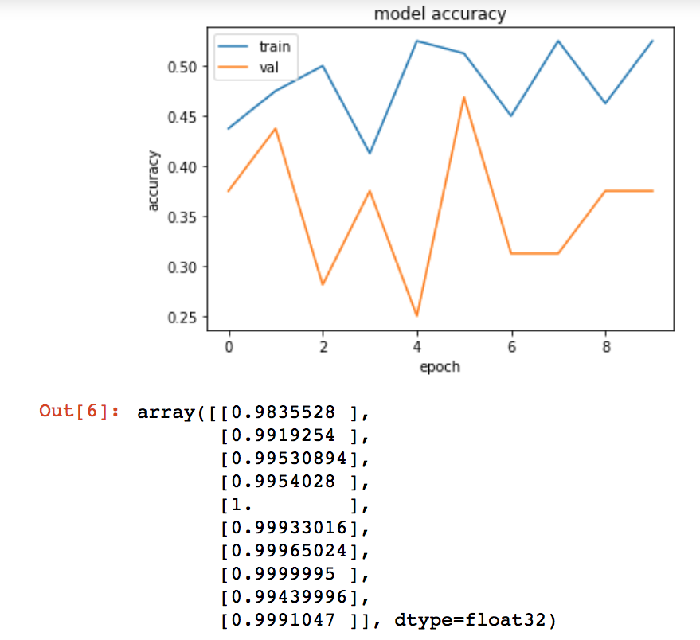

So something was not right.

This lead into a week of exploring regularisation and optimisers, in the desparate attempt of getting the network working.

Through this, I learned a very helpful command prompt for listing all files in a folder:

`$ 'ls' > files.csv`

I then tried variety of optimisers, and learning rates (as I later found out that the learning rate was responsible for all the fluctuations, and the opimiser, to a degree, can affect the accuracy and the stability of a neural network). I said the following in my log:

*Changed the optimiser to 'Adam', and changed the learning rate to '0.0001' (default = '0.001'), ran the code for 7 epochs. I also changed the batch size to 32. You can see that both the training set and validation set curves are a lot smoother. While the validation set still fluctuates, the range is a lot more normal/managable. There is apparently a 'sweet spot' to learning rate, so I'll have a look into that. (the graph looks different because I changed the graph style in as a part of my attempt to have a live graph)*

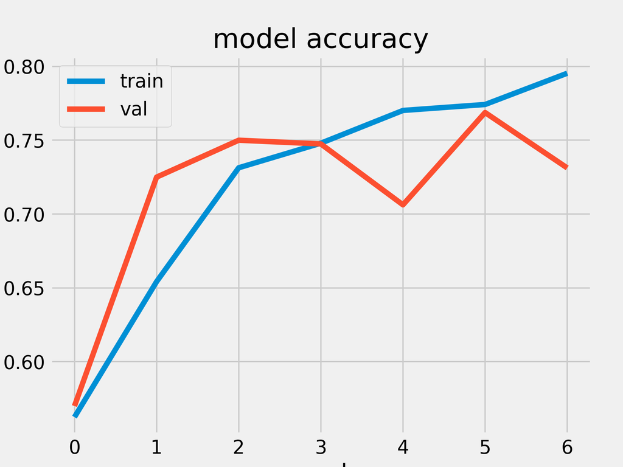

But yes, let's hope it stablises!

At the moment, I don't think that's the case - definitely not stablising, if anything, it's becoming very unstable. I then decided that it's not worth spending lots of time doing a live graph). The training set is looking very happy though (it's giving consistent results! :D ):</i>

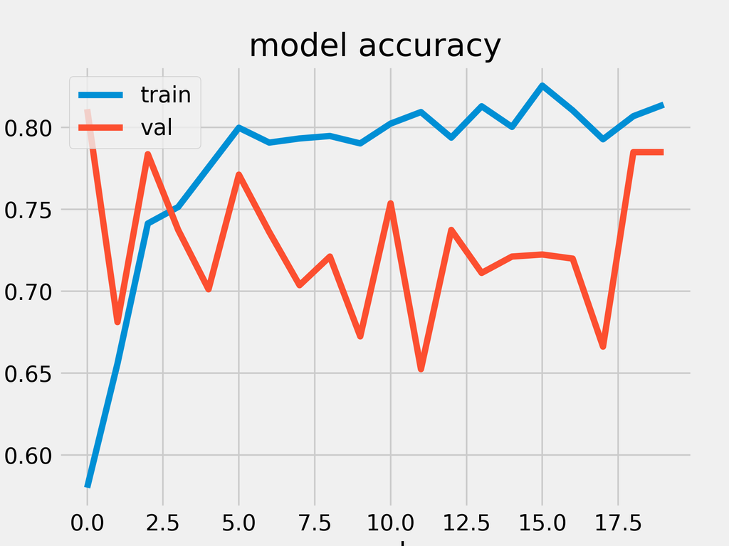

As one can see, the program was not producing consistent results. After a bit of research, I found that the use of a seed can help. This is what I noted in my notes:

*Ok, I changed the seed to '1337' instead of '1', and turned multiprocessing off, as suggested in one of the posts. Why '1337'? Because it's not 1. Ok, being serious, I changed it in the hopes that the results will be more consistent, because sometimes, putting 1 in a random number generator is not a good idea, and one of the comments just happened to use 1337, so I went with it. Hope this goes well!*

I then further changed some parameters after filtering thorugh possible causes of fluctuations on stack exchange and GitHub. One suggestion was to turn multiprocessing off, so I did, and made a note in my log:

This lead to a more accurate graph, which was good news:

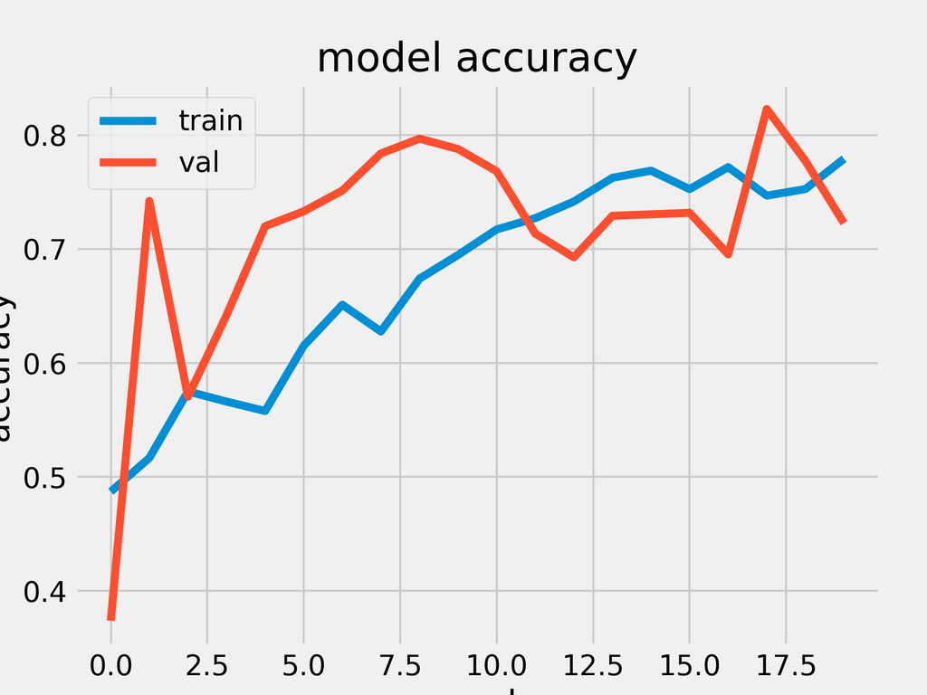

After some more testing, I decided to stick with the SGD optimiser with a learning rate of lr=0.001, which gave the following accuracy:

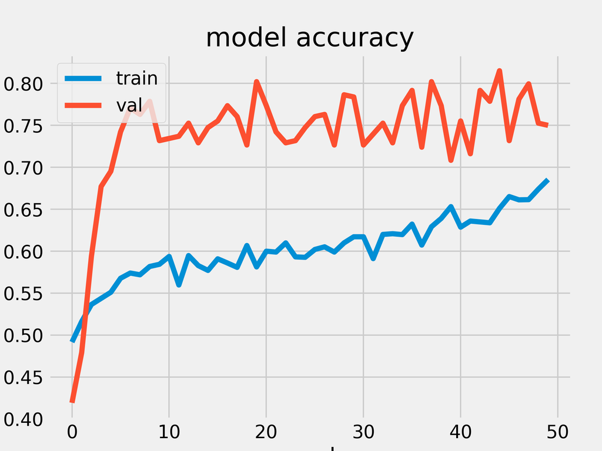

And came across a blog detailing how all the labels are assigned through an image generator:

*Finally understood how my code's labelling work, which is talked about here, in the section'The Issue': https://medium.com/difference-engine-ai/keras-a-thing-you-should-know-about-keras-if-you-plan-to-train-a-deep-learning-model-on-a-large-fdd63ce66bd2*

It basically creates an array mapping of all the direcoties and the files within them :)</i>

So after leaving the code to run over the weeked, I got a good graph for the accuracy:

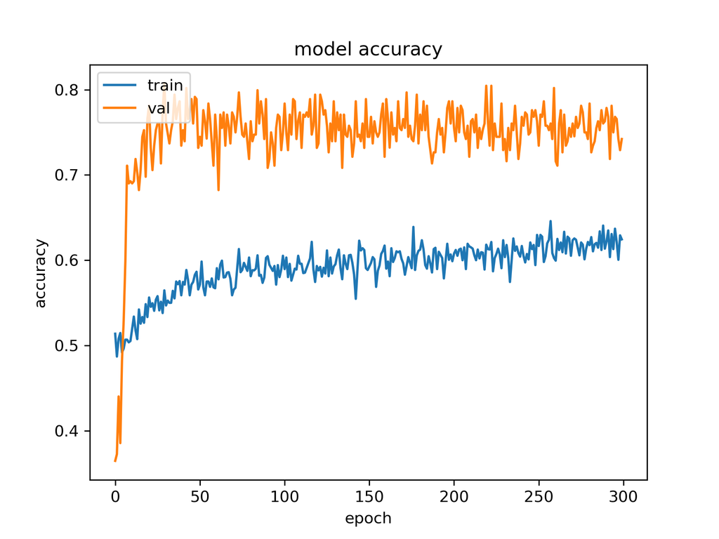

It was the first plot to show consistency over 300 epochs, which meant I had dealt with most of the problems in my neural network.

As I had sucesssfully trained a network (and technically made predictions, but had no idea how to retrieve them), I spent a long time trying to work out how to make one. The biggest issue came from labels, and having to constantly rerun the network was not at all practical. So the decision was made that I would save the trained model, and reloaded it to make predictions using a rewritten prediction code in a different folder (so now I have a train_cnn.py and a predict_cnn.py)

After that, I implemented some metrics functions, but for details, see Week5.ipynb.

I made a histogram that showed all the predictions, but I couldn't get all the original labels as well as the predicted labels:

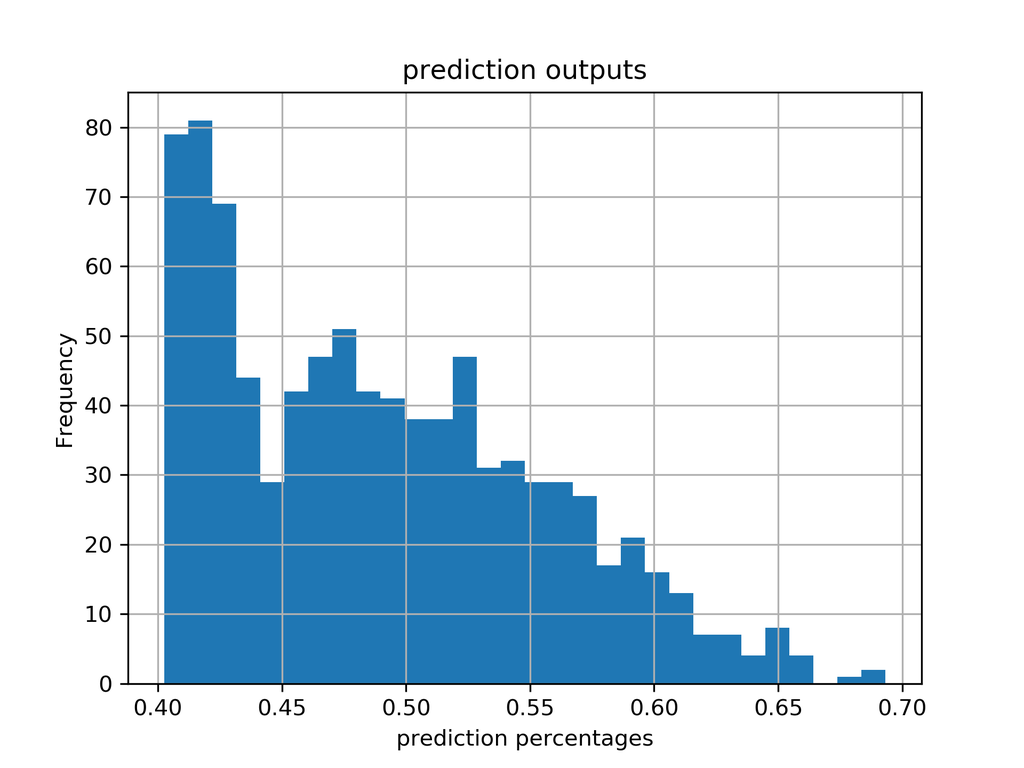

After encountering numerous problems with loading file names into pandas and back into lists, I asked Brooke for help, and finally had a working list of true and predicted labels for the images, albeit in Jupyter Notebook due to compability issues with the syntax. Very soon, I hanaged to have a ROC curve, followed by an AUC score and a precision recall graph.

ROC curve:

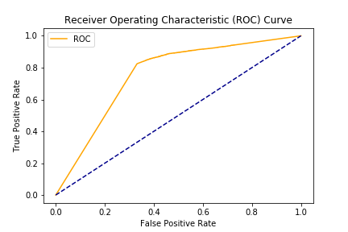

Precision Recall Curve:

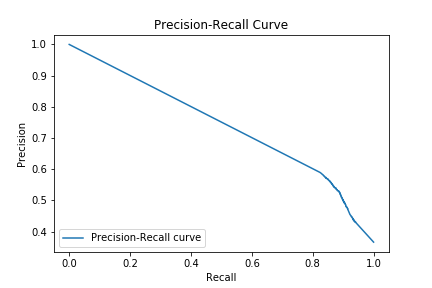

The list of files used to produce the results are as follows:

- `train_cnn.py`
- `brookes_code.ipynb`

Other files, though many, are test files which I tested code from, or used to follow tutorials with, but the two listed are the final working files.